# How Students Use Devices at University

## Introduction

The data was gathered by observing students on campus at the University of Auckland. It keeps track of their primary device (e.g., Macbook, Windows), whether they used the newly added monitors, what activity they were doing (e.g., studying, watching, typing), and whether they used multiple devices.

The goal is to better understand how students use digital devices for studying.

## Study Activities of Students by Device Type

In the first plot, I analyzed how students engage in different study activities depending on their device type. The plot shows the count of students performing activities such as taking notes, watching lectures, or doing assignments across three device types: Macbook, Windows, and Chromebook.

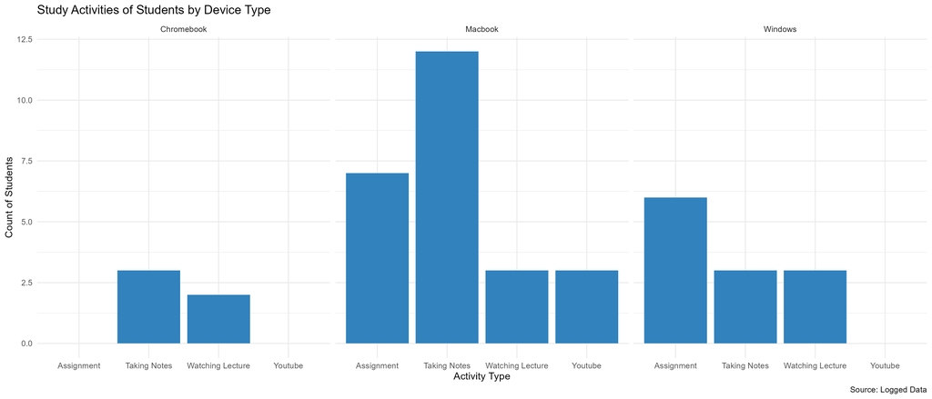

Bar chart showing student study activities split by device type. Macbooks are most common, with varied activities.

## Activity by the number of devices used by students.

The second plot explores how the number of devices students use impacts the types of activities they engage in. Some students use only one device, while others multitask with two or more devices. This plot highlights whether using multiple devices leads to a greater variety of activities or if students prefer to focus on one device for a single activity, which this information will not be 100% correct due to the little amount of data gathered for Chromebook users.

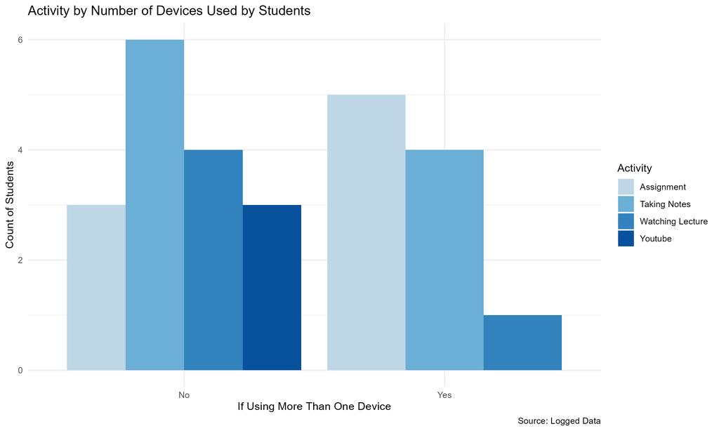

Grouped bar chart showing study activities by whether students used multiple devices.